# Individual Differences in Procedural and Conceptual Fraction Learning

Aishah Bakhtiar

05 December, 2015

## Research Background

Mathematical cognition researchers often discuss students’ acquisition of two types of math knowledge: conceptual and procedural (e.g., Rittle-Johnson & Siegler, 1998.  
**Conceptual knowledge** refers to the ability to meaningfully understand separate pieces of information that exists in a subject domain, and to “know that” those pieces of information are interconnected in some ways.  
**Procedural knowledge** is an implicit type of knowledge that is formed by performing a set or sets of actions. In the mathematics domain, procedural knowledge is interchangeably referred to as math computational skills. This skill involves “knowing how” to use mathematical symbols and to apply rules pertaining to the mathematical problems at hand.

In addition to conceptual and procedural knowledge being different ways of thinking, recent research has suggested that there are different profiles in how people learn these types of knowledge (e.g., Hallett, Nunes, & Bryant, 2010; Hallett, Nunes, Bryant, & Thorpe, 2012). Some people can be classified as relying more on conceptual knowledge (referred to as conceptual learners), while others can be classified as relying more on procedural knowledge (referred to as procedural learners).

## Objectives

In this report, I aim to examine whether procedural and conceptual fraction learners can be differentiated based on motivation characteristics. In doing so, I will first cluster the learners using their residualized procedural and conceptual fraction scores. These residualized scores represent the part of conceptual (or procedural) scale that was independent of the other knowledge type. For example, if a student had a positive conceptual residualized score, this means that the student had a higher conceptual score than would be predicted given the student’s procedural score.

#### Load Packages

Prepare RStudio environment for all tasks to follow.

```r
# Load the necessary packages.
base::require(base)
base::require(knitr)
base::require(markdown)
base::require(testit)
base::require(dplyr)
base::require(reshape2)
base::require(stringr)
base::require(stats)
base::require(ggplot2)
base::require(extrafont)
base::require(gridExtra)
```

Access to this data is limited to researchers listed on the research ethics application.

```r
data <- read.csv("./data/derived/data.csv")
```

## Cluster Analysis

It is possible that within a procedural and a conceptual cluster, there is a mixture between high-ability and low-ability learners. High-ability learners can be described as having perfomed well on both procedural and conceptual scales. In constrast, low-ability learners are those who performed poorly on the same two scales. This mixture between high-low ability in procedural or conceptual cluster may result in having no significant differences in motivation scores between the two groups. Thus, a four-cluster solution is chosen in order to separate out high-ability and low-ability learners from the procedural and conceptual clusters.This 4-cluster solution has proven to have a good fit with sample collected in Hallett et al. (2010).

```r
# kmeanstests and numclustertests functions written by Hallett et al. (2011)
source("scripts/kmeanstests.R")
source("scripts/numclustertests.R")
membership = as.data.frame(data$SuperCluster, k = 2:10)
ClusterData = data.frame(cbind(scale(data[c("con_rdw", "pro_rdw", "procon_tot")]), membership))
koutput <- kmeanstests(ClusterData[,1:3],membership)
```

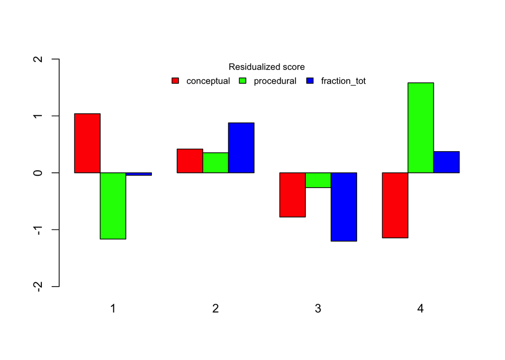

```
    Solution         C(g)         L(m)            p  Low Cluster High Cluster
      4.0000     208.9174           NA           NA           NA           NA
```

```r
koutput$means$Clusters4
```

```
        con_rdw    pro_rdw  procon_tot
[1,]  1.0390468 -1.1653168 -0.04389007
[2,]  0.4177111  0.3523485  0.87772630
[3,] -0.7771040 -0.2605169 -1.20204891
[4,] -1.1444954  1.5816686  0.37350588
```

| Cluster Number | Label |
| --- | --- |
| 1 | Conceptual Learners |
| 2 | High Achievers |
| 3 | Low Achievers |
| 4 | Procedural Learners |

##### Chi Square Analysis: Gender x Cluster

```r
library(gmodels)
CrossTable(data$Gender, data$SuperCluster, chisq=TRUE)
```

```
   Cell Contents
|-------------------------|
|                       N |
| Chi-square contribution |
|           N / Row Total |
|           N / Col Total |
|         N / Table Total |
|-------------------------|


Total Observations in Table:  251


             | data$SuperCluster
 data$Gender |         1 |         2 |         3 |         4 | Row Total |
-------------|-----------|-----------|-----------|-----------|-----------|
           1 |        37 |        48 |        44 |        15 |       144 |
             |     0.739 |     0.096 |     0.638 |     5.309 |           |
             |     0.257 |     0.333 |     0.306 |     0.104 |     0.574 |
             |     0.661 |     0.600 |     0.647 |     0.319 |           |
             |     0.147 |     0.191 |     0.175 |     0.060 |           |
-------------|-----------|-----------|-----------|-----------|-----------|
           2 |        19 |        32 |        24 |        32 |       107 |
             |     0.995 |     0.130 |     0.858 |     7.144 |           |
             |     0.178 |     0.299 |     0.224 |     0.299 |     0.426 |
             |     0.339 |     0.400 |     0.353 |     0.681 |           |
             |     0.076 |     0.127 |     0.096 |     0.127 |           |
-------------|-----------|-----------|-----------|-----------|-----------|
Column Total |        56 |        80 |        68 |        47 |       251 |
             |     0.223 |     0.319 |     0.271 |     0.187 |           |
-------------|-----------|-----------|-----------|-----------|-----------|


Statistics for All Table Factors


Pearson's Chi-squared test
------------------------------------------------------------
Chi^2 =  15.90851     d.f. =  3     p =  0.001184027
```

**Section Summary**

From the table above, we may see that there is a large proportion of males in the conceptual group and a large proportion of females in the procedural group. In other words, in the mid-range ability group, females tend to rely more on procedural skills and males tend to rely more on conceptual skills

```r
# in dsL procon_tot, con_rdw, pro_rdw are updated with new values from above cluster analysis
# new labels = procon_tot.y, con_rdw.y, con_rdw.y
dsL = merge(data,ClusterData, by="row.names")
rownames(dsL) <- dsL$ID
```

```r
# Select variable of interest and work with a smaller dataset. There's more to delete than select.
dsA <- subset(dsL, , select= c("Subject",
                                "School",
                                "Gender",
                                "Age",
                                "con_tot",
                                "pro_tot",
                                "procon_tot.y",
                                "MSC_Tot",
                                "MathSuccess_Ability",
                                "MathSuccess_Effort",
                                "MathSuccess_External",
                                "MathFailure_Ability",
                                "MathFailure_Effort",
                                "MathFailure_External",
                                "Mastery_Tot",
                                "PApproach_Tot",
                                "PAvoid_Tot",
                                "con_rdw.y",
                                "pro_rdw.y",
                                "SuperCluster",
                                "Work_Con",
                                "Work_Pro"))
dsA$clusterF= factor(dsA$SuperCluster)
dsA$SuperCluster <- factor(dsA$SuperCluster,
                    levels = c(1,2,3,4),
                    labels = c("con", "hi", "lo", "pro"))
```

### Question 1:Which motivation variables are important in predicting performance on the fraction test?

Best subset selection is performed from a pool of motivation variables

```r
library(leaps)
regfit.best=regsubsets(procon_tot.y~MSC_Tot+
                        MathSuccess_Ability+
                        MathSuccess_Effort+
                        MathSuccess_External+
                        MathFailure_Ability+
                        MathFailure_Effort+
                        MathFailure_External+
                        Mastery_Tot+
                        PApproach_Tot+
                        PAvoid_Tot, data=dsA)
reg.summary=summary(regfit.best)
which.max(reg.summary$adjr2)
```

```
[1] 6
```

```r
which.min(reg.summary$cp)
```

```
[1] 5
```

```r
which.min(reg.summary$bic)
```

```
[1] 3
```

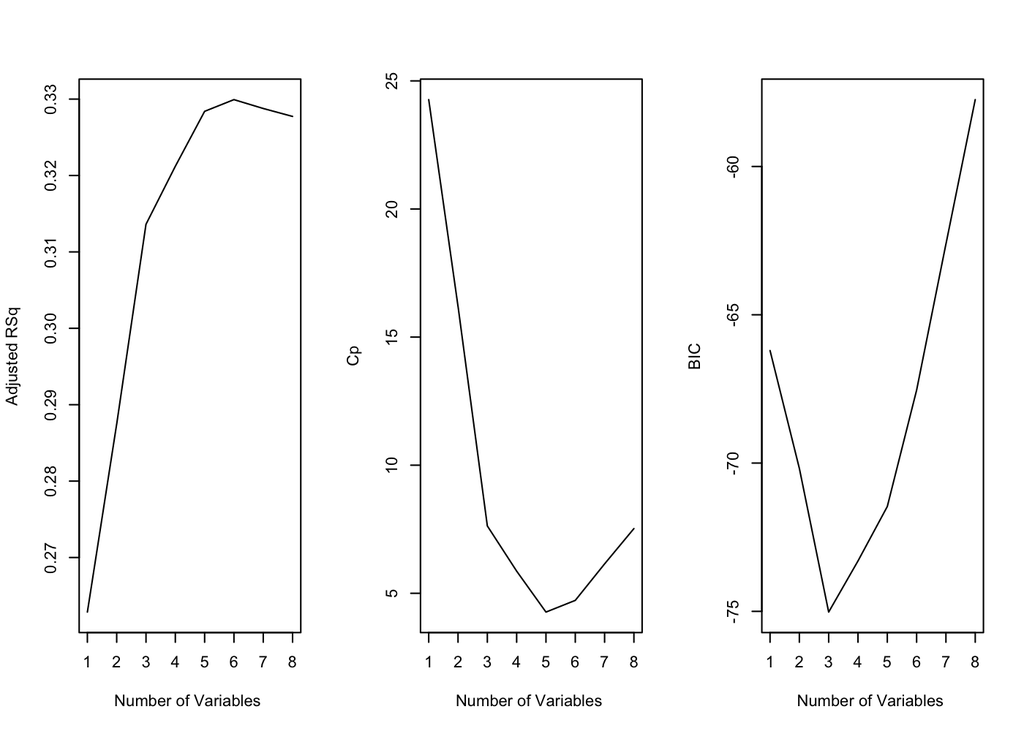

```r
par(mfrow=c(1,3))
plot(reg.summary$adjr2 ,xlab="Number of Variables ",ylab="Adjusted RSq",type="l")
plot(reg.summary$cp ,xlab="Number of Variables ",ylab="Cp", type="l")
plot(reg.summary$bic ,xlab="Number of Variables ",ylab="BIC",type="l")
```

```r
# Given the statistics above, a model that includes 3 variables is best
coef(regfit.best,3)
```

```
        (Intercept)             MSC_Tot MathSuccess_Ability         Mastery_Tot
        -1.31852039          0.03986243          0.03848091         -0.05548368
```

**Section Summary**

As demonstrated in the plot above, beyond 3-predictor model, the BIC value tends to increase as the model gets more complex. Hence, the best number of variables to include in a model is around 3-4 variables. Fraction performance can be best predicted by how favourable one perceived one’s math ability (math self-concept), one’s tendency to attribute previous math successes to ability, and one’s tendency to approach a learning situation with a goal to master the content (mastery orientation).

Below is a series of scatterplot showing the relation between fraction performance and each of the motivation variable in the model:

Side note: For mainTheme script, refer to this [link](https://github.com/andkov/psy532/blob/master/scripts/graphs/main_theme.R)

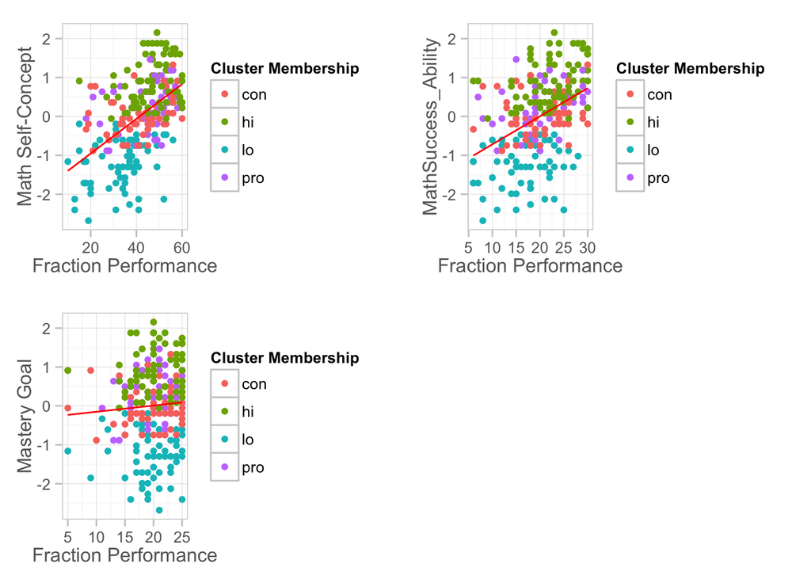

```r
# mainTheme is written by Github user- andkov
source("scripts/mainTheme.R")
# plot 1
g1 <- ggplot(data=dsA, aes(x=MSC_Tot,y=procon_tot.y)) +
  geom_point(aes(color=factor(SuperCluster), aplha=.4)) +
  geom_smooth(method="lm", se=FALSE, size=0.5, color="red", alpha=.5) +
  main_theme +
  labs(x="Fraction Performance", y="Math Self-Concept") +
  guides(color = guide_legend(title="Cluster Membership"))
#   ggtitle("Fraction performance as a function of\nmath self-concept") +
#   theme(plot.title = element_text(lineheight=.8, face="bold"))
# plot 2
g2 <- ggplot(data=dsA, aes(x=MathSuccess_Ability, y=procon_tot.y)) +
  geom_point(aes(color=factor(SuperCluster), aplha=.4)) +
  geom_smooth(method="lm", se=FALSE, size=0.5, color="red", alpha=.5) +
  main_theme +
  labs(x="Fraction Performance", y="MathSuccess_Ability") +
  guides(color = guide_legend(title="Cluster Membership"))
#   ggtitle("Fraction performance as a function of\nability attribution for math success") +
#   theme(plot.title = element_text(lineheight=.8, face="bold"))
# plot 3
g3 <- ggplot(data=dsA, aes(x=Mastery_Tot, y=procon_tot.y)) +
  geom_point(aes(color=factor(SuperCluster), aplha=.4)) +
  geom_smooth(method="lm", se=FALSE, size=0.5, color="red", alpha=.5) +
  main_theme +
  labs(x="Fraction Performance", y="Mastery Goal") +
  guides(color = guide_legend(title="Cluster Membership"))
#   ggtitle("Fraction performance as a function of\nmastery goal orientation") +
#   theme(plot.title = element_text(lineheight=.8, face="bold"))
# g1
# g2
# g3
# plot all
grid.arrange(g1,g2,g3, ncol=2, nrow=2, heights=3000, widths=50)
```

### Question 2: How are the clusters different in terms of motivation characteristics?

#### I. Math Self-Concept and Clusters

```r
anova <- aov(MSC_Tot ~ clusterF, data=dsA)
summary(anova)
```

```
             Df Sum Sq Mean Sq F value   Pr(>F)
clusterF      3   6841  2280.3   21.47 2.18e-12 ***
Residuals   246  26123   106.2
---
Signif. codes:  0 '***' 0.001 '**' 0.01 '*' 0.05 '.' 0.1 ' ' 1
1 observation deleted due to missingness
```

```r
# run post-hoc comparison
with(dsA, pairwise.t.test(MSC_Tot, clusterF, p.adj="bonferroni", paired=F))
```

```
    Pairwise comparisons using t tests with pooled SD

data:  MSC_Tot and clusterF

  1       2       3
2 0.01766 -       -
3 0.00031 2.4e-12 -
4 0.52824 1.00000 2.0e-07

P value adjustment method: bonferroni
```

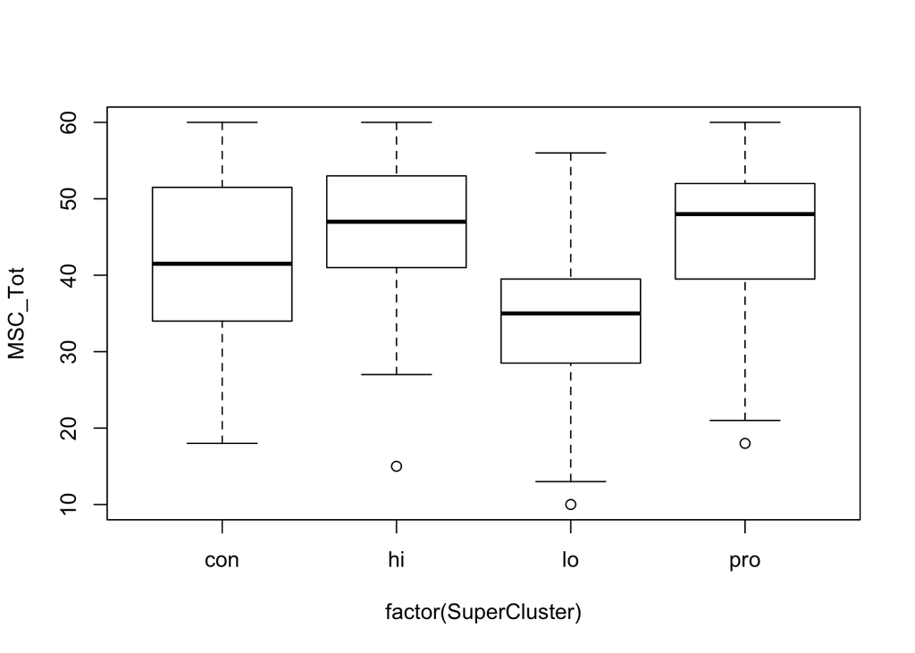

```r
plot(MSC_Tot~factor(SuperCluster), data=dsA)
```

**Section Summary**

Althogh proecedural and conceptual learners are not significantly different in terms of math self-concept, the conceptual learners are significantly different from the high achievers. This suggests a trend that conceptual learners tend to have lower math self-concept than procedural learners.

#### II. Attribution Style and Clusters

```r
# For past successes
dsRepL <- readRDS("./data/derived/dsRepL.rds")
dsRep.Success <- dsRepL[grep("MathSuccess-*", dsRepL$attribution.type), ]
aov.rep = aov(attribution.score ~ attribution.type * factor(SuperCluster) + Error(Subject/attribution.type), data=dsRep.Success)
summary(aov.rep)
```

```
Error: Subject
                      Df Sum Sq Mean Sq F value   Pr(>F)
factor(SuperCluster)   3    664  221.31   6.446 0.000322 ***
Residuals            246   8445   34.33
---
Signif. codes:  0 '***' 0.001 '**' 0.01 '*' 0.05 '.' 0.1 ' ' 1

Error: Subject:attribution.type
                                       Df Sum Sq Mean Sq F value   Pr(>F)
attribution.type                        2   2440  1219.9  57.073  < 2e-16 ***
attribution.type:factor(SuperCluster)   6    624   103.9   4.862 7.72e-05 ***
Residuals                             492  10516    21.4
---
Signif. codes:  0 '***' 0.001 '**' 0.01 '*' 0.05 '.' 0.1 ' ' 1
```

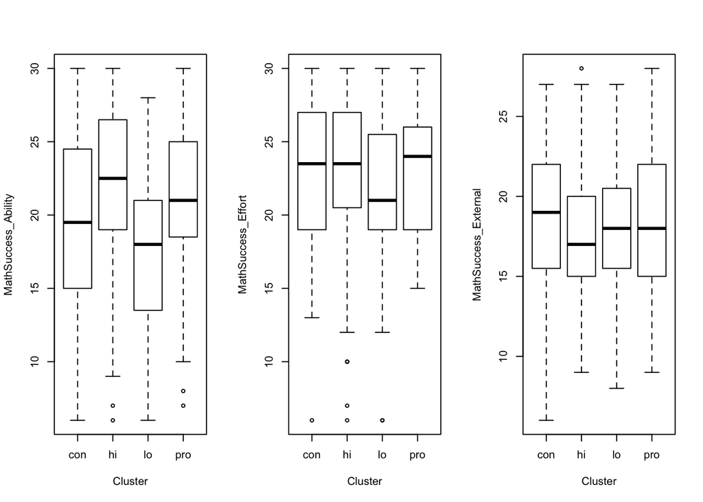

```r
par(mfrow=c(1,3))
plot(MathSuccess_Ability~factor(SuperCluster), data=dsA, xlab="Cluster")
plot(MathSuccess_Effort~factor(SuperCluster), data=dsA, xlab="Cluster")
plot(MathSuccess_External~factor(SuperCluster), data=dsA, xlab="Cluster")
```

```r
# For past failures
dsRep.Fail <- dsRepL[grep("MathFail-*", dsRepL$attribution.type), ]
aov.rep2 = aov(attribution.score ~ attribution.type * factor(SuperCluster) + Error(Subject/attribution.type), data=dsRep.Fail)
summary(aov.rep2)
```

```
Error: Subject
                      Df Sum Sq Mean Sq F value   Pr(>F)
factor(SuperCluster)   3    611  203.70   6.993 0.000156 ***
Residuals            246   7166   29.13
---
Signif. codes:  0 '***' 0.001 '**' 0.01 '*' 0.05 '.' 0.1 ' ' 1

Error: Subject:attribution.type
                                       Df Sum Sq Mean Sq F value   Pr(>F)
attribution.type                        2   1968   984.1  66.278  < 2e-16 ***
attribution.type:factor(SuperCluster)   6    728   121.4   8.177 1.91e-08 ***
Residuals                             492   7305    14.8
---
Signif. codes:  0 '***' 0.001 '**' 0.01 '*' 0.05 '.' 0.1 ' ' 1
```

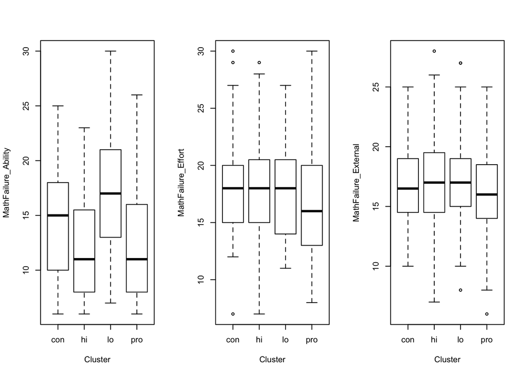

```r
par(mfrow=c(1,3))
plot(MathFailure_Ability~factor(SuperCluster), data=dsA, xlab="Cluster")
plot(MathFailure_Effort~factor(SuperCluster), data=dsA, xlab="Cluster")
plot(MathFailure_External~factor(SuperCluster), data=dsA, xlab="Cluster")
```

**Section Summary**

Two sets of a two-way repeated measure Anova were performed with attribution type (within-subject variable) and cluster membership (between-subject variable). Both tests reveal a significant interaction between attribution.type and cluster membership.

#### III. Goal Orientation and Cluster

```r
dsRepGoal <- readRDS("./data/derived/dsRepGoal.rds")
aov.rep3 = aov(goal.score ~ goal.type * factor(SuperCluster) + Error(Subject/goal.type), data=dsRepGoal)
summary(aov.rep3)
```

```
Error: Subject
                      Df Sum Sq Mean Sq F value Pr(>F)
factor(SuperCluster)   3    156   51.98   1.556  0.201
Residuals            246   8218   33.40

Error: Subject:goal.type
                                Df Sum Sq Mean Sq F value Pr(>F)
goal.type                        2  11631    5816  407.40 <2e-16 ***
goal.type:factor(SuperCluster)   6     35       6    0.41  0.872
Residuals                      492   7023      14
---
Signif. codes:  0 '***' 0.001 '**' 0.01 '*' 0.05 '.' 0.1 ' ' 1
```

**Section Summary**

A two-way repeated measure, with goal type being the within-subject variable and cluster membership being the between-subject variable, reveal no significant interaction between goal type and cluster membership. This suggest all clusters’ goal orientation patterns are relatively similar.

## Conclusions

In this analysis, fraction learners were grouped into four clusters: (i) procedural, (ii) conceptual, (iii) high achievers, (iv) low achievers. The proportion of males and females in both the procedural and conceptual clusters was significantly different; more males were considered as conceptual leaners and more females were considered as procedural learners. In addition, the learners’ differences were examined based on their math self-concept, attribution styles, and goal orientation. Although the learners were no different in terms of the goals they adopt for learning math, they were different in the way they appraised their math self-concept and in the way they attribute past successes and failures.

```r
pathdsLcsv <- "./data/derived/dsA.csv"
write.csv(dsA,pathdsLcsv,  row.names=FALSE)
```

```r
rm(list=setdiff(ls(), c("dsA", "dsL")))
```

## References

Hallett, D., Nunes, T., & Bryant, P. (2010). Individual differences in conceptual and procedural knowledge when learning fractions. *Journal of Educational Psychology, 102*(2), 395-406.

Hallett, D., Nunes, T., Bryant, P., & Thorpe, C. M. (2012). Individual differences in conceptual and procedural fraction understanding: The role of abilities and school experience. *Journal of Experimental Child Psychology, 113*(4), 469-486.

Rittle-Johnson, B., & Siegler, R. S. (1998). The relation between conceptual and procedural knowledge in learning mathematics: A review. In C. Donlan (Ed.), *The development of mathematical skills* (pp. 75–110). East Sussex, UK: Psychology Press.